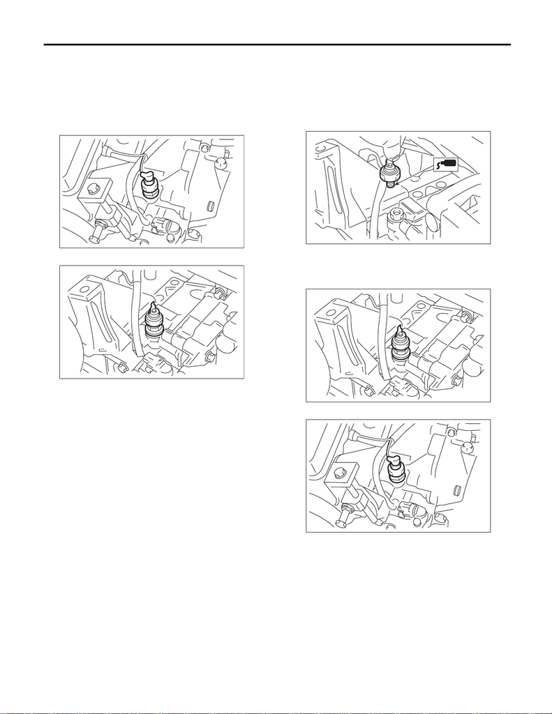

LU(STI)-22

Oil Pressure Switch

LUBRICATION

6. Oil Pressure Switch

A: REMOVAL

1) Disconnect the ground cable from battery.

2) Remove the generator from the bracket. <Ref. to

SC(STI)-15, REMOVAL, Generator.>

3) Disconnect the terminal from oil pressure switch.

4) Remove the oil pressure switch.

B: INSTALLATION

1) Apply liquid gasket to the oil pressure switch

threads.

Liquid gasket:

THREE BOND 1324 (Part No. 004403042) or

equivalent

2) Install the oil pressure switch to cylinder block.

Tightening torque:

25 N·m (2.5 kgf-m, 18.4 ft-lb)

3) Connect the terminal to the oil pressure switch.

4) Install the generator to the bracket. <Ref. to

SC(STI)-15, INSTALLATION, Generator.>

5) Connect the battery ground terminal.

C: INSPECTION

1) Check that the oil pressure switch does not have

deformation, cracks or damage.

2) Check that there are no oil leaks or oil oozing

from the oil pressure switch installation portion.

LU-00036

LU-00037

LU-00038

LU-00037

LU-00036